# Diplomatura en BIG DATA

Data Mining & Machine Learning

Escalada Christian, 33.549.575

01-06-2022

[figure not shown]

# Trabajo Práctico N° 2

## Aprendizaje Supervisado

$$\\[1in]$$

## Parte A – Preprocesamiento de los datos.

#### 1.1. Ingrese a la página web de la Universidad de California.

[Universidad de California](https://archive.ics.uci.edu/ml/datasets/seeds)

#### 1.2. Descargue el archivo `seeds_dataset.txt`.

seeds_dataset.txt

#### 1.3. Copie aquí el Abstract.

> Abstract:

> Measurements of geometrical properties of kernels belonging to three different varieties of wheat. A soft X-ray technique and GRAINS package were used to construct all seven, real-valued attributes.

#### 2.1. Busque en la página web e indique aquí: ¿cuáles son las 3 variedades de trigo que se estudiarán?

> Data Set Information:

> The examined group comprised kernels belonging to three different varieties of wheat: **Kama**, **Rosa** and **Canadian**, 70 elements each, randomly selected for the experiment.
- Las 3 variedades a estudiar son: **Kama**, **Rosa**, **Canadian**.

#### 2.2. Optativo: busque una imagen de granos de trigo. Indique la página web origen de dicha imagen.

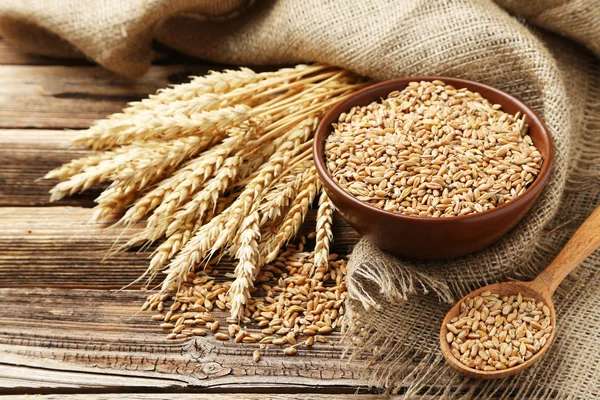

Fuente: depositphotos.com [^1]

#### 3.1. Abra el archivo seeds_dataset.txt en R como “base” de la siguiente manera:

```r
base=read.table("seeds_dataset.txt",header=F)
```

#### 3.2. Muestre un `head(base)`.

```r
head(base)
```

```
##      V1    V2     V3    V4    V5    V6    V7 V8
## 1 15.26 14.84 0.8710 5.763 3.312 2.221 5.220  1
## 2 14.88 14.57 0.8811 5.554 3.333 1.018 4.956  1
## 3 14.29 14.09 0.9050 5.291 3.337 2.699 4.825  1
## 4 13.84 13.94 0.8955 5.324 3.379 2.259 4.805  1
## 5 16.14 14.99 0.9034 5.658 3.562 1.355 5.175  1
## 6 14.38 14.21 0.8951 5.386 3.312 2.462 4.956  1
```

#### 3.3. Renombre cada variable:

```r
names(base)[names(base)=="V1"]="Area"
names(base)[names(base)=="V2"]="Perimetro"
names(base)[names(base)=="V3"]="Compactitud"
names(base)[names(base)=="V4"]="Largo"
names(base)[names(base)=="V5"]="Ancho"
names(base)[names(base)=="V6"]="Asimetria"
names(base)[names(base)=="V7"]="Division"
names(base)[names(base)=="V8"]="Variedad"
```

#### 3.4. Muestre un `head(base)` con el cambio de las variables.

```r
head(base)
```

```
##    Area Perimetro Compactitud Largo Ancho Asimetria Division Variedad
## 1 15.26     14.84      0.8710 5.763 3.312     2.221    5.220        1
## 2 14.88     14.57      0.8811 5.554 3.333     1.018    4.956        1
## 3 14.29     14.09      0.9050 5.291 3.337     2.699    4.825        1
## 4 13.84     13.94      0.8955 5.324 3.379     2.259    4.805        1
## 5 16.14     14.99      0.9034 5.658 3.562     1.355    5.175        1
## 6 14.38     14.21      0.8951 5.386 3.312     2.462    4.956        1
```

#### 4.1. Transforme a categórica la variable Variedad y renombre las variedades 1, 2 y 3 como “kama”, “rosa” y “canadian”:

```r
base$Variedad=factor(base$Variedad,levels=c(1,2,3),
                     labels=c("kama","rosa","canadian"))
```

#### 4.2. Muestre un head de la base con las variables transformadas.

```r
head(base)
```

```
##    Area Perimetro Compactitud Largo Ancho Asimetria Division Variedad
## 1 15.26     14.84      0.8710 5.763 3.312     2.221    5.220     kama
## 2 14.88     14.57      0.8811 5.554 3.333     1.018    4.956     kama
## 3 14.29     14.09      0.9050 5.291 3.337     2.699    4.825     kama
## 4 13.84     13.94      0.8955 5.324 3.379     2.259    4.805     kama
## 5 16.14     14.99      0.9034 5.658 3.562     1.355    5.175     kama
## 6 14.38     14.21      0.8951 5.386 3.312     2.462    4.956     kama
```

## Parte B – Análisis Exploratorio de Datos.

#### 1. ¿Cuántas semillas hay por variedad?

```r
summary(base$Variedad)
```

```
##     kama     rosa canadian
##       70       70       70
```

- Existen **70** Semillas por Variedad.

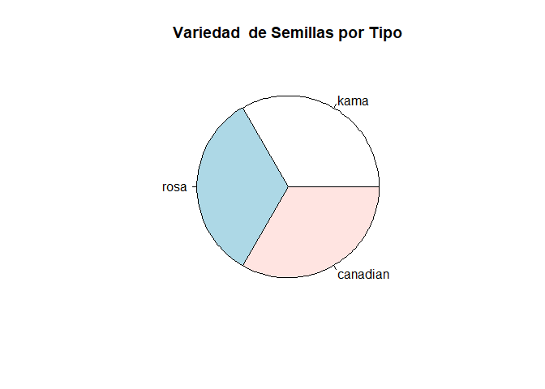

```r
pie(table(base$Variedad),main="Variedad  de Semillas por Tipo")
```

#### 3. Realice un gráfico de dispersión:

- Entre 2 variables que no sean Variedad.
- coloréelo por la variable Variedad.
- agregue una leyenda que indique cuál es cada grupo.
- Elija las variables en y & x, un título y un pch.

```r
# Importamos Librerias:
library(caret)
```

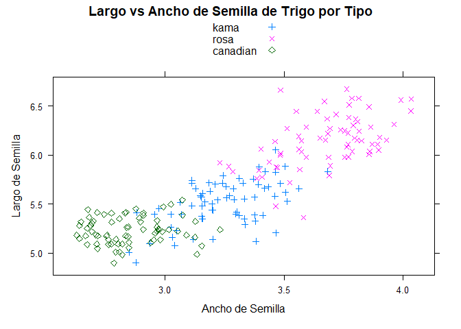

```r
xyplot(base$Largo~base$Ancho,groups=base$Variedad,base,auto.key=TRUE,
       par.settings=simpleTheme(pch=c(3,4,5)),pch=c(3,4,5),
       main="Largo vs Ancho de Semilla de Trigo por Tipo",
       xlab="Ancho de Semilla", ylab="Largo de Semilla")
```

#### 4.1. Con la instrucción `base[numFila,]` se puede obtener los datos de uno de los granos de trigo.

- Considere los 2 últimos dígitos de su DNI: `(75)`.
- Muestre aquí el registro correspondiente.

```r
trigo=base[75,]
trigo
```

```
##     Area Perimetro Compactitud Largo Ancho Asimetria Division Variedad
## 75 16.82     15.51      0.8786 6.017 3.486     4.004    5.841     rosa
```

4.2. ¿De qué variedad es?

- Se trata de la Variedad **ROSA** el Tipo de Semilla que me tocó.

## Parte C - Conjuntos.

#### 1.1. Considere los **3** últimos dígitos de su DNI `(3numDNI)` para el seteo de semilla.

- Mis 3 últimos números de mi DNI son: **575**.

#### 1.2. Particione la base en un conjunto de **Entrenamiento** y uno de **Testeo**.

- Además:
  - Si su DNI termina en 0, 1, 2 ó 3:
    - Setee **p=0.70**
  - Si su DNI termina en 4, 5, 6 ó 7:
    - Setee **p=0.75**
  - Si su DNI termina en 8 ó 9:
    - Setee **p=0.80**
- Mi último número de DNI es **5**.
- p va a ser igual a **0.75**.

```r
# El código va a quedar:
set.seed(575);particion=createDataPartition(y=base$Variedad,p=0.75,list=FALSE)

entreno= base[particion,]
testeo=  base[-particion,]
```

#### 2. Muestre un head y un summary del conjunto de Entrenamiento y del conjunto de Testeo.

```r
# Head Entrenamiento:
head(entreno)
```

```
##    Area Perimetro Compactitud Largo Ancho Asimetria Division Variedad
## 2 14.88     14.57      0.8811 5.554 3.333     1.018    4.956     kama
## 3 14.29     14.09      0.9050 5.291 3.337     2.699    4.825     kama
## 5 16.14     14.99      0.9034 5.658 3.562     1.355    5.175     kama
## 7 14.69     14.49      0.8799 5.563 3.259     3.586    5.219     kama
## 8 14.11     14.10      0.8911 5.420 3.302     2.700    5.000     kama
## 9 16.63     15.46      0.8747 6.053 3.465     2.040    5.877     kama
```

```r
# Head Testeo:
head(testeo)
```

```
##     Area Perimetro Compactitud Largo Ancho Asimetria Division Variedad
## 1  15.26     14.84      0.8710 5.763 3.312     2.221    5.220     kama
## 4  13.84     13.94      0.8955 5.324 3.379     2.259    4.805     kama
## 6  14.38     14.21      0.8951 5.386 3.312     2.462    4.956     kama
## 12 14.03     14.16      0.8796 5.438 3.201     1.717    5.001     kama
## 13 13.89     14.02      0.8880 5.439 3.199     3.986    4.738     kama
## 14 13.78     14.06      0.8759 5.479 3.156     3.136    4.872     kama
```

```r
# Summary Entrenamiento:
summary(entreno)
```

```
##       Area         Perimetro      Compactitud         Largo
##  Min.   :10.59   Min.   :12.41   Min.   :0.8081   Min.   :4.899
##  1st Qu.:12.31   1st Qu.:13.46   1st Qu.:0.8578   1st Qu.:5.263
##  Median :14.37   Median :14.37   Median :0.8724   Median :5.541
##  Mean   :14.86   Mean   :14.56   Mean   :0.8711   Mean   :5.629
##  3rd Qu.:17.22   3rd Qu.:15.71   3rd Qu.:0.8865   3rd Qu.:5.989
##  Max.   :21.18   Max.   :17.25   Max.   :0.9153   Max.   :6.666
##      Ancho         Asimetria         Division         Variedad
##  Min.   :2.648   Min.   :0.7651   Min.   :4.519   kama    :53
##  1st Qu.:2.947   1st Qu.:2.5505   1st Qu.:5.045   rosa    :53
##  Median :3.242   Median :3.5980   Median :5.263   canadian:53
##  Mean   :3.261   Mean   :3.6648   Mean   :5.412
##  3rd Qu.:3.557   3rd Qu.:4.6940   3rd Qu.:5.877
##  Max.   :4.033   Max.   :8.4560   Max.   :6.498
```

```r
# Summary Testeo:
summary(testeo)
```

```
##       Area         Perimetro      Compactitud         Largo
##  Min.   :10.74   Min.   :12.73   Min.   :0.8099   Min.   :4.984
##  1st Qu.:12.26   1st Qu.:13.43   1st Qu.:0.8560   1st Qu.:5.261
##  Median :14.11   Median :14.21   Median :0.8763   Median :5.479
##  Mean   :14.82   Mean   :14.55   Mean   :0.8707   Mean   :5.627
##  3rd Qu.:17.29   3rd Qu.:15.70   3rd Qu.:0.8883   3rd Qu.:5.926
##  Max.   :20.71   Max.   :17.23   Max.   :0.9183   Max.   :6.675
##      Ancho         Asimetria        Division         Variedad
##  Min.   :2.630   Min.   :0.903   Min.   :4.738   kama    :17
##  1st Qu.:2.933   1st Qu.:2.570   1st Qu.:5.002   rosa    :17
##  Median :3.232   Median :3.631   Median :5.180   canadian:17
##  Mean   :3.252   Mean   :3.811   Mean   :5.395
##  3rd Qu.:3.570   3rd Qu.:4.878   3rd Qu.:5.835
##  Max.   :3.930   Max.   :8.315   Max.   :6.550
```

#### 3.1. Realice:

- `summary(base$Variedad)`
- `summary(entreno$Variedad)`
- `summary(testeo$Variedad)`

```r
summary(base$Variedad)
```

```
##     kama     rosa canadian
##       70       70       70
```

```r
summary(entreno$Variedad)
```

```
##     kama     rosa canadian
##       53       53       53
```

```r
summary(testeo$Variedad)
```

```
##     kama     rosa canadian
##       17       17       17
```

#### 3.2. ¿Cuántos registros quedaron por variedad de trigo en el conjunto de entrenamiento y en el de testeo?

- En el Conjunto de Entrenamiento quedaron **53** registros por variedad de trigo.
- En el Conjunto de Testeo quedaron **17** registros por variedad de trigo.

## Parte D – Árbol de Decisión

#### 1.1. Cree un Árbol de Decisión (con librería rpart) para modelar el problema planteado.

```r
# Importamos Librerias:
library(rpart)
```

```r
arbol=rpart(Variedad~.,entreno,method="class")
```

#### 1.2. Escriba arbol y muestre una captura de pantalla de la información que aparece.

```r
arbol
```

```
## n= 159
##
## node), split, n, loss, yval, (yprob)
##       * denotes terminal node
##
##  1) root 159 106 kama (0.33333333 0.33333333 0.33333333)
##    2) Division>=5.618 52   1 rosa (0.01923077 0.98076923 0.00000000) *
##    3) Division< 5.618 107  54 canadian (0.48598131 0.01869159 0.49532710)
##      6) Area>=13.41 42   2 kama (0.95238095 0.04761905 0.00000000) *
##      7) Area< 13.41 65  12 canadian (0.18461538 0.00000000 0.81538462)
##       14) Asimetria< 3.24 11   2 kama (0.81818182 0.00000000 0.18181818) *
##       15) Asimetria>=3.24 54   3 canadian (0.05555556 0.00000000 0.94444444) *
```

#### 2. Grafique el Árbol de Decisión resultante.

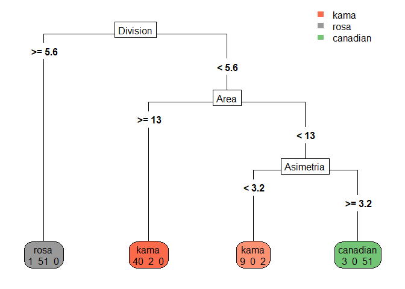

```r
# Importamos Librerias:
library(rpart.plot)

#Graficamos el AdD
rpart.plot(arbol,extra=1,type=5)
```

#### 3. ¿Cuántas “hojas” tiene el Árbol de Decisión?

- El Árbol de Decisión tiene 4 hojas.

#### 4.1. Según el Árbol de Decisión creado, ¿cuándo una semilla es de la variedad “rosa”?

- Según mi AdD, la semilla es de variedad **Rosa** cuando la variable predictora **División** es Mayor o Igual a **5.6** unidades.

#### 4.2. Indique las reglas siguiendo las ramas desde el nodo raíz hasta las hojas “rosa”.

- Si **División** es **Mayor/Igual** a **5.6**, entonces el tipo de semilla es **Rosa**.
- Si **División** es **Menor** a **5.6**, entonces preguntamos:
  - Si **Área** es **Mayor/Igual** a **13**, entonces el tipo de semilla es **Kama**.
  - Si **Área** es **Menor** a **13**, entonces preguntamos:
    - Si **Asimetría** es **Mayor/Igual** a **3.2**, entonces el tipo de semilla es **Canadian**.
    - Si **Asimetría** es **Menor** a **3.2**, entonces el tipo de semilla es **Kama**.

#### 5.1. Testee el Árbol de Decisión.

```r
pred=predict(arbol,testeo,type="class")
```

#### 5.2. Compare: `head(pred,10)` con `head(test$Variedad,10)`.

```r
head(pred,10)
```

```
##        1        4        6       12       13       14       17       20
##     kama     kama     kama     kama     kama     kama     kama canadian
##       22       26
##     kama     kama
## Levels: kama rosa canadian
```

```r
head(testeo$Variedad,10)
```

```
##  [1] kama kama kama kama kama kama kama kama kama kama
## Levels: kama rosa canadian
```

#### 5.3. Vea si la predicción de los 10 primeros elementos coincide con lo esperado.

- En líneas Generales podemos afirmar que la predicción del AdD coincide con lo esperado en Test, ya que predijo **Kama** a todos los elementos, excepto a uno que lo clasificó como **Canadian**.

#### 6.1. Calcule la matriz de confusión y muestre los resultados obtenidos.

```r
confusionMatrix(pred,testeo$Variedad)
```

```
## Confusion Matrix and Statistics
##
##           Reference
## Prediction kama rosa canadian
##   kama       16    0        4
##   rosa        0   17        0
##   canadian    1    0       13
##
## Overall Statistics
##
##                Accuracy : 0.902
##                  95% CI : (0.7859, 0.9674)
##     No Information Rate : 0.3333
##     P-Value [Acc > NIR] : < 2.2e-16
##
##                   Kappa : 0.8529
##
##  Mcnemar's Test P-Value : NA
##
## Statistics by Class:
##
##                      Class: kama Class: rosa Class: canadian
## Sensitivity               0.9412      1.0000          0.7647
## Specificity               0.8824      1.0000          0.9706
## Pos Pred Value            0.8000      1.0000          0.9286
## Neg Pred Value            0.9677      1.0000          0.8919
## Prevalence                0.3333      0.3333          0.3333
## Detection Rate            0.3137      0.3333          0.2549
## Detection Prevalence      0.3922      0.3333          0.2745
## Balanced Accuracy         0.9118      1.0000          0.8676
```

#### 7.1. Calcule el Accuracy según la cantidad de registros bien clasificados.

- **Fórmula**:

$$Accuracy = \frac{\text{Diagonal
Aciertos}}{Total}$$

- Cantidad de Registros bien clasificados:
  - **Kama**: 16.
  - **Rosa**: 17.
  - **Canadian**: 13.

#### 7.2. Indique con números la fórmula que usó.

$$Acc = \frac{(17 + 16 + 13)}{(17 + 17 +
17)}$$

#### 7.3. Verifique que coincida con el Accuracy obtenido por confusionMatrix.

```
## El Accuracy obtenido en este punto es: 0.902 ; Cuyo valor coincide
## con el Acc obtenido por la Matriz de Confusión del punto 6.1.
```

#### 9.1. Considere el grano de trigo correspondiente a los últimos 2 dígitos de su DNI.

- Mis 2 últimos números de mi DNI son: **75**.

#### 9.2. Según el Árbol de Decisión, ¿qué variedad es?

```r
predict(arbol,trigo,type="class")
```

```
##   75
## rosa
## Levels: kama rosa canadian
```

- Según el AdD, la Semilla del Índice **75**, correspondería a la variedad: **Rosa**.

#### 9.3. ¿Coincide la predicción con lo esperado?

```r
trigo
```

```
##     Area Perimetro Compactitud Largo Ancho Asimetria Division Variedad
## 75 16.82     15.51      0.8786 6.017 3.486     4.004    5.841     rosa
```

- La Variedad esperada es **Rosa**, por lo tanto podemos afirmar que si **coinciden** ambos resultados.

#### 10. Indique la predicción de “Trigo” con probabilidades.

```r
predict(arbol,trigo)
```

```
##          kama      rosa canadian
## 75 0.01923077 0.9807692        0
```

- El AdD Predice que nuestro Trigo (`base[75,]`) va a ser **Rosa** con un **98%** de confianza.

#### 11. Indique la regla del Árbol de Decisión para “Trigo”.

```r
rpart.predict(arbol, trigo, rules=TRUE)
```

```
##          kama      rosa canadian
## 75 0.01923077 0.9807692        0 because Division >= 5.6
```

- Cuando seteamos `rules=TRUE`, aparece en pantalla `Division >= 5.6` para clasificar nuestra semilla a la variedad **Rosa**.

## Parte E – Red Neuronal.

#### 1.1. Considere los 3 últimos dígitos de su DNI (3numDNI) para el seteo de semilla.

- Mis 3 últimos números de mi DNI son: **575**.

#### 1.2. Cree una Red Neuronal para modelar el problema planteado.

- Con:
  - maxit=10000
  - size=10.

```r
# Importamos Librerías:
library(nnet)
library(NeuralNetTools)
```

#### 1.3. Indique el código R utilizado.

```
set.seed(575);red=nnet(Variedad~.,entreno,size=10,maxit=10000)
```

#### 2. Muestre una captura de pantalla de la lista de iteraciones de la Red Neuronal.

```r
set.seed(575);red=nnet(Variedad~.,entreno,size=10,maxit=10000)
```

[output not shown]

#### 3. Escriba red y muestre una captura de pantalla de la información que aparece.

```r
red
```

```
## a 7-10-3 network with 113 weights
## inputs: Area Perimetro Compactitud Largo Ancho Asimetria Division
## output(s): Variedad
## options were - softmax modelling
```

#### 5.1. Dibuje la Red Neuronal.

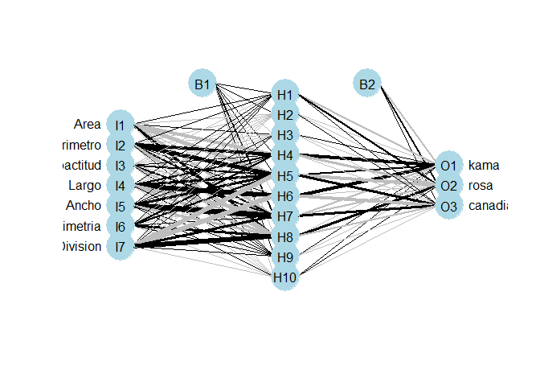

```r
plotnet(red)
```

#### 5.2. Cambiar los colores del gráfico de la Red Neuronal.

$$\text{Gráfico de la Red Neuronal}$$

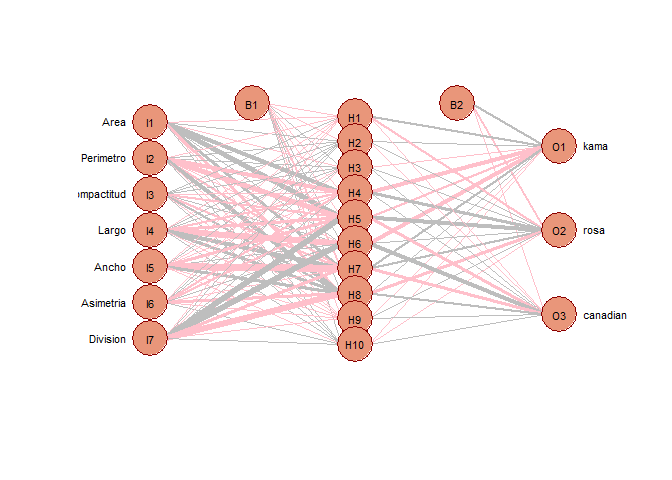

#### 6.1. Testee la Red Neuronal.

```r
pred2=predict(red,testeo,type="class")
```

#### 6.2. Compare `head(pred2,10)` con `head(testeo$Variedad,10)`.

```r
# Observamos la predicción:
head(pred2,10)
```

```
##  [1] "kama"     "kama"     "kama"     "kama"     "kama"     "kama"
##  [7] "canadian" "canadian" "kama"     "kama"
```

```r
# Observamos Test:
head(testeo$Variedad,10)
```

```
##  [1] kama kama kama kama kama kama kama kama kama kama
## Levels: kama rosa canadian
```

#### 6.3. Vea si la predicción de los 10 primeros elementos coincide con lo esperado.

- La predicción de los primeros 10 elementos en General coincide, salvo 2 elementos que la Red predijo como **Canadian** cuando lo esperado era que prediga **Kama**.

#### 7. Calcule la matriz de confusión y muestre los resultados obtenidos.

```r
confusionMatrix(factor(pred2),testeo$Variedad)
```

```
## Confusion Matrix and Statistics
##
##           Reference
## Prediction kama rosa canadian
##   kama       14    0        2
##   rosa        0   17        0
##   canadian    3    0       15
##
## Overall Statistics
##
##                Accuracy : 0.902
##                  95% CI : (0.7859, 0.9674)
##     No Information Rate : 0.3333
##     P-Value [Acc > NIR] : < 2.2e-16
##
##                   Kappa : 0.8529
##
##  Mcnemar's Test P-Value : NA
##
## Statistics by Class:
##
##                      Class: kama Class: rosa Class: canadian
## Sensitivity               0.8235      1.0000          0.8824
## Specificity               0.9412      1.0000          0.9118
## Pos Pred Value            0.8750      1.0000          0.8333
## Neg Pred Value            0.9143      1.0000          0.9394
## Prevalence                0.3333      0.3333          0.3333
## Detection Rate            0.2745      0.3333          0.2941
## Detection Prevalence      0.3137      0.3333          0.3529
## Balanced Accuracy         0.8824      1.0000          0.8971
```

#### 8. ¿Cuál fue el Accuracy?

- El Accuracy fue de **0.902**.

#### 9.1. Considere el grano de trigo correspondiente a los últimos 2 dígitos de su DNI.

- Mis 2 últimos números de mi DNI son: 75.

#### 9.2. Según la Red Neuronal, ¿qué variedad es?

```r
predict(red,trigo,type="class")
```

```
## [1] "rosa"
```

- Según la Red Neuronal, la Semilla del Índice **75**, correspondería a la variedad: **Rosa**.

#### 9.3. ¿Coincide la predicción con la variedad esperada?

```r
trigo
```

```
##     Area Perimetro Compactitud Largo Ancho Asimetria Division Variedad
## 75 16.82     15.51      0.8786 6.017 3.486     4.004    5.841     rosa
```

- La Variedad esperada es **Rosa**, por lo tanto podemos afirmar que si **coinciden** ambos resultados.

## Parte F – Comparación de modelos.

#### 1. Cree una tabla con el **Accuracy** de cada modelo, y la **Sensibilidad** y **Especificidad** de cada modelo por categoría.

| Variedad | AdD Accuracy | RN Accuracy | AdD Sensibilidad | RN Sensibilidad | AdD Especificidad | RN Especificidad |
| --- | --- | --- | --- | --- | --- | --- |
| **Kama** | 0.902 | 0.902 | 0.9412 | 0.8235 | 0.8824 | 0.9412 |
| **Rosa** | 0.902 | 0.902 | 1.0000 | 1.0000 | 1.0000 | 1.0000 |
| **Canadian** | 0.902 | 0.902 | 0.7647 | 0.8824 | 0.9706 | 0.9118 |

#### 2.1. Compare los resultados obtenidos con el Árbol de Decisión y la Red Neuronal.

#### 2.2. ¿Cuál modelo le parece que resultó mejor?

- Con Respecto al mejor modelo, creo que no hay un claro Ganador.

#### 2.3. ¿Según qué criterio?

- El **criterio** en el cual fundamento mi postura es que:
  - Para ambos modelos, el **Accuracy** es el mismo valor:

  $$\Sigma Accuracy_{AdD} = \Sigma
  Accuracy_{RN} = 0.902$$
  - Con Respecto a la **Sensibilidad**, que es la **tasa de verdaderos positivos**:[^2]
    - En General son altas en ambos modelos, eso es bueno ya que: Cuanto mayor es la Sensibilidad, la tasa de **FN** será menor[^3], por lo que la cantidad de Semillas que pertenecen a una variedad y fueron clasificadas como otra variedad, se reduce.
    - Para la variedad **Rosa**, ambos modelos presentan el mismo valor.
    - Para la variedad **Kama**, la Sensibilidad del AdD resultó mayor que de la RN.
    - Para la variedad **Canadian**, la Sensibilidad de la RN resultó ser mayor.
    - Pero en el **Global** la Sumatoria de la Sensibilidad en ambos modelos, da el mismo resultado:

    $$\Sigma Sensibilidad_{AdD} = \Sigma
    Sensibilidad_{RN} = 2.7059$$
  - Con Respecto a la **Especificidad**, que es la **tasa de verdaderos negativos**:[^4]
  - En General son altas en ambos modelos, eso es bueno ya que: Cuanto mayor es la Especificidad, la tasa de **FP** será menor[^5], por lo que la cantidad de Semillas que fueron clasificadas como una determinada variedad, pero en realidad son de otra variedad, se reduce.
    - Para la variedad **Rosa**, ambos modelos presentan el mismo valor.
    - Para la variedad **Kama**, la Especificidad del RN resultó mayor que de la AdD.
    - Para la variedad **Canadian**, la Especificidad de la AdD resultó ser mayor.
    - Pero en el **Global** la Sumatoria de la Especificidad en ambos modelos, da el mismo resultado:

    $$\Sigma Especificidad_{AdD} = \Sigma
    Especificidad_{RN} = 2.853$$
- En base a este breve argumento baso mi criterio de considerar que no hubo un claro Ganador respecto a estos dos modelos de Machine Learning analizados con este Dataset de Semillas de Trigo. Habría que utilizar otros Datasets para volver a comparar sus performances con nuevos datos.

## Anexo.

#### Código:

```
Parte A – Preprocesamiento de los datos.
base=read.table("seeds_dataset.txt",header=F)
head(base)
names(base)[names(base)=="V1"]="Area"
names(base)[names(base)=="V2"]="Perimetro"
names(base)[names(base)=="V3"]="Compactitud"
names(base)[names(base)=="V4"]="Largo"
names(base)[names(base)=="V5"]="Ancho"
names(base)[names(base)=="V6"]="Asimetria"
names(base)[names(base)=="V7"]="Division"
names(base)[names(base)=="V8"]="Variedad"
head(base)
base$Variedad=factor(base$Variedad,levels=c(1,2,3),
                     labels=c("kama","rosa","canadian"))
head(base)

Parte B – Análisis Exploratorio de Datos.
summary(base$Variedad)
pie(table(base$Variedad),main="Variedad  de Semillas por Tipo")
library(caret)
xyplot(base$Largo~base$Ancho,groups=base$Variedad,base,auto.key=TRUE,
       par.settings=simpleTheme(pch=c(3,4,5)),pch=c(3,4,5),
       main="Largo vs Ancho de Semilla de Trigo por Tipo",
       xlab="Ancho de Semilla", ylab="Largo de Semilla")
trigo=base[75,]
trigo
set.seed(575);particion=createDataPartition(y=base$Variedad,p=0.75,list=FALSE)
entreno= base[particion,]
testeo=  base[-particion,]
head(entreno)
head(testeo)
summary(entreno)
summary(testeo)
summary(base$Variedad)
summary(entreno$Variedad)
summary(testeo$Variedad)

Parte D – Árbol de Decisión
library(rpart)
arbol=rpart(Variedad~.,entreno,method="class")
```

[output cut: 15 more lines]

```
plotnet(red,
        circle_col = "darksalmon",
        pos_col = "pink",
        neg_col = "grey",
        bord_col = "darkred",
        circle_cex=5,
        alpha_val=1,
        cex_val=0.70,
        max_sp= TRUE)
pred2=predict(red,testeo,type="class")
head(pred2,10)
head(testeo$Variedad,10)
confusionMatrix(factor(pred2),testeo$Variedad)
predict(red,trigo,type="class")
trigo
```

#### Librerias:

```
library(caret)
library(rpart)
library(rpart.plot)
library(nnet)
library(NeuralNetTools)
```

### Bibliografia:

- [Centrar Títulos](https://es.stackoverflow.com/questions/452933/es-posible-centrar-t%C3%ADtulos-en-markdown-para-generar-pdf)
- [Centrar Textos](https://foroayuda.es/r-como-centrar-la-salida-en-r-markdown/#google_vignette)
- [How-to-add-whitespace](https://stackoverflow.com/questions/24425786/how-to-add-whitespace-to-an-rmarkdown-document)
- [Wheet Grains](https://www.nestle-cereals.com/ac/sites/g/files/fawtmp321/files/styles/stage_visual_large_webp/public/d7/article_switching_to_wholegrain_2048x1152_01_2.jpg.webp?itok=XnPBZfBy)
- [Árboles de Decisión I](https://es.wikipedia.org/wiki/Aprendizaje_basado_en_árboles_de_decisión#Limitaciones)
- [Árboles de Decisión II](https://bookdown.org/content/2031/arboles-de-decision-parte-i.html)
- [Algoritmo CART](https://www.codificandobits.com/blog/clasificacion-arboles-decision-algoritmo-cart/)
- [Fórmula Latex](https://wiki.geogebra.org/es/Código_LaTeX_para_las_fórmulas_más_comunes)
- [Plotnet](https://www.rdocumentation.org/packages/NeuralNetTools/versions/1.5.3/topics/plotnet)
- [Plotnet](https://search.r-project.org/CRAN/refmans/NeuralNetTools/html/plotnet.html)
- [R Colors](http://applied-r.com/wp-content/uploads/2019/01/rcolors_byname.png)
- [Plots](https://rpubs.com/Rortizdu/140112)
- [Markdown Tables](https://www.markdownguide.org/basic-syntax/#emphasis)
- [Sensibilidad-Especificidad](https://www.cigna.com/es-us/individuals-families/health-wellness/hw/sensibilidad-y-especificidad-sts14487)
- [Sensibilidad-Especificidad](https://www.sac.org.ar/cuestion-de-metodo/que-son-sensibilidad-y-especificidad/)

# ¡Muchas Gracias!

[figure not shown]

[^1]: [depositphotos.com](https://st2.depositphotos.com/4278641/7727/i/600/depositphotos_77271764-stock-photo-ears-of-wheat-and-bowl.jpg)
[^2]: [Sensibilidad](https://www.cigna.com/es-us/individuals-families/health-wellness/hw/sensibilidad-y-especificidad-sts14487)
[^3]: [Explicación Sensibilidad](https://www.sac.org.ar/cuestion-de-metodo/que-son-sensibilidad-y-especificidad/)
[^4]: [Especificidad](https://www.cigna.com/es-us/individuals-families/health-wellness/hw/sensibilidad-y-especificidad-sts14487)
[^5]: [Explicación Especificidad](https://www.sac.org.ar/cuestion-de-metodo/que-son-sensibilidad-y-especificidad/)